# Genting Malaysia-GENM

## Data Import

Time series data which is regarding to the stock price of Genting Malaysia is imported. Its data type is converted into time series(ts) object before the further actions are carried out.

```r
#Import data
data = read.csv(file.choose(), stringsAsFactors = F)

#Convert to time series data type
data1 = ts(data[, 2])
```

## Volatility

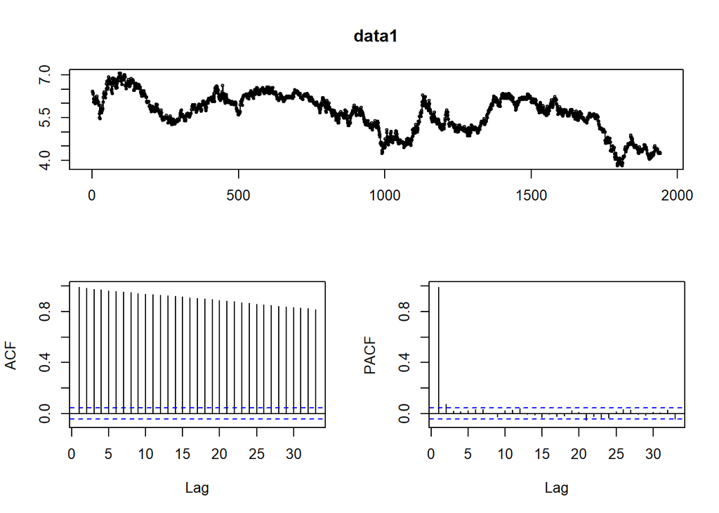

```r
#Load library
library(forecast)

#Check volatility
lambda = BoxCox.lambda(data1)
data1 = BoxCox(data1, lambda = lambda)
tsdisplay(data1)
```

## Stationary

```r
#Load library
library(tseries)

#ADF
adf = adf.test(data1)

#KPSS
kpss = kpss.test(data1)
```

Two tests have been used to detect the stationary of data. One of the test is Augmented Dickey-Fuller test(ADF) and another is Kwiatkowski-Phillips-Schmidt-Shin(KPSS) test.

```
    Augmented Dickey-Fuller Test

data:  data1
Dickey-Fuller = -2.2424, Lag order = 12, p-value = 0.4757
alternative hypothesis: stationary
```

Since the p-value of the ADF test is greater than the significance level of 0.05, thus it indicates that the data is non-stationary.

```
    KPSS Test for Level Stationarity

data:  data1
KPSS Level = 8.064, Truncation lag parameter = 8, p-value = 0.01
```

For the KPSS test, the p-value of it is less than 0.05, thus it also indicates that the data is non-stationary.

## Differencing

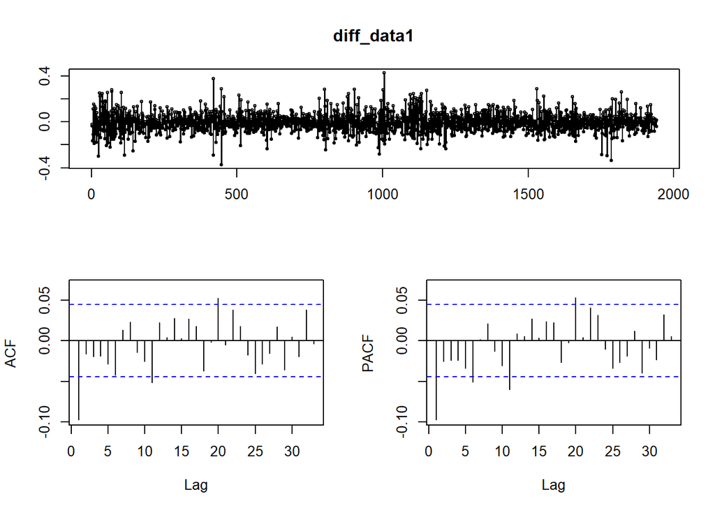

```r
diff_data1 = diff(data1)
tsdisplay(diff_data1)
```

First difference method is applied due to the non-stationarity of the data.

## Model Identification and Estimation

```r
#Fast method
auto.arima(data1, trace = T, ic = "aicc", approximation = F)
```

```
 ARIMA(2,1,2) with drift         : -4356.224
 ARIMA(0,1,0) with drift         : -4338.349
 ARIMA(1,1,0) with drift         : -4354.789
 ARIMA(0,1,1) with drift         : -4355.682
 ARIMA(0,1,0)                    : -4339.969
 ARIMA(1,1,2) with drift         : -4357.976
 ARIMA(0,1,2) with drift         : -4354.56
 ARIMA(1,1,1) with drift         : -4357.533
 ARIMA(1,1,3) with drift         : -4356.513
 ARIMA(0,1,3) with drift         : -4354.012
 ARIMA(2,1,1) with drift         : -4358.115
 ARIMA(2,1,0) with drift         : -4354.043
 ARIMA(3,1,1) with drift         : -4356.449
 ARIMA(3,1,0) with drift         : -4353.133
 ARIMA(3,1,2) with drift         : -4354.16
 ARIMA(2,1,1)                    : -4359.464
 ARIMA(1,1,1)                    : -4358.906
 ARIMA(2,1,0)                    : -4355.561
 ARIMA(3,1,1)                    : -4357.802
 ARIMA(2,1,2)                    : -4357.575
 ARIMA(1,1,0)                    : -4356.329
 ARIMA(1,1,2)                    : -4359.325
 ARIMA(3,1,0)                    : -4354.63
 ARIMA(3,1,2)                    : -4355.507

 Best model: ARIMA(2,1,1)
```

```
Series: data1
ARIMA(2,1,1)

Coefficients:
         ar1     ar2      ma1
      0.7111  0.0434  -0.8147
s.e.  0.0905  0.0275   0.0873

sigma^2 estimated as 0.006173:  log likelihood=2183.74
AIC=-4359.49   AICc=-4359.46   BIC=-4337.2
```

```r
#Slow method with higher accurancy
auto.arima(data1, trace = T, ic = "aicc", approximation = T)
```

```
 Fitting models using approximations to speed things up...

 ARIMA(2,1,2) with drift         : -4351.437
 ARIMA(0,1,0) with drift         : -4333.273
 ARIMA(1,1,0) with drift         : -4348.802
 ARIMA(0,1,1) with drift         : -4350.616
 ARIMA(0,1,0)                    : -4334.893
 ARIMA(1,1,2) with drift         : -4353.451
 ARIMA(0,1,2) with drift         : -4349.493
 ARIMA(1,1,1) with drift         : -4352.484
 ARIMA(1,1,3) with drift         : -4351.79
 ARIMA(0,1,3) with drift         : -4348.944
 ARIMA(2,1,1) with drift         : -4353.492
 ARIMA(2,1,0) with drift         : -4347.269
 ARIMA(3,1,1) with drift         : -4351.155
 ARIMA(3,1,0) with drift         : -4345.594
 ARIMA(3,1,2) with drift         : -4348.765
 ARIMA(2,1,1)                    : -4354.976
 ARIMA(1,1,1)                    : -4353.915
 ARIMA(2,1,0)                    : -4348.809
 ARIMA(3,1,1)                    : -4352.652
 ARIMA(2,1,2)                    : -4352.666
 ARIMA(1,1,0)                    : -4350.35
 ARIMA(1,1,2)                    : -4354.908
 ARIMA(3,1,0)                    : -4347.129
 ARIMA(3,1,2)                    : -4350.261

 Now re-fitting the best model(s) without approximations...

 ARIMA(2,1,1)                    : -4359.464

 Best model: ARIMA(2,1,1)
```

```
Series: data1
ARIMA(2,1,1)

Coefficients:
         ar1     ar2      ma1
      0.7111  0.0434  -0.8147
s.e.  0.0905  0.0275   0.0873

sigma^2 estimated as 0.006173:  log likelihood=2183.74
AIC=-4359.49   AICc=-4359.46   BIC=-4337.2
```

```r
#Fit model
finalmodel = Arima(data1, order = c(2, 1, 1))

#Summary of model
summary(finalmodel)
```

```
Series: data1
ARIMA(2,1,1)

Coefficients:
         ar1     ar2      ma1
      0.7111  0.0434  -0.8147
s.e.  0.0905  0.0275   0.0873

sigma^2 estimated as 0.006173:  log likelihood=2183.74
AIC=-4359.49   AICc=-4359.46   BIC=-4337.2

Training set error measures:
                       ME       RMSE        MAE         MPE     MAPE
Training set -0.001463766 0.07848551 0.05804016 -0.04041339 1.040497
                 MASE        ACF1
Training set 1.000479 0.000250667
```

There are two ways in proposing time series model. Both of the ways suggest that ARIMA(2,1,1) is the most appropriate time series model for the data. Thus, based on the function of **auto.arima**, ARIMA(2,1,1) is used to forecast the stock price of Genting Malaysia.

## Residual Diagnostics

### Independency

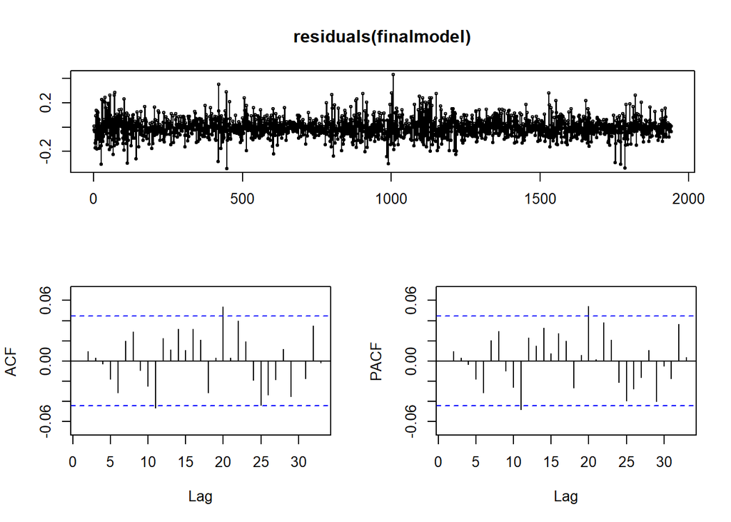

```r
#Independency of residuals
tsdisplay(residuals(finalmodel))
```

```r
Box.test(finalmodel$residuals, lag = 20, type = "Ljung-Box")
```

```
    Box-Ljung test

data:  finalmodel$residuals
X-squared = 24.703, df = 20, p-value = 0.213
```

```r
#Critical chi-square value
qchisq(0.05, 20, lower.tail = F)
```

```
[1] 31.41043
```

Since chi-square value, 24.703 is less than 31.41, so the null hypothesis is not rejected. It indicates that the residuals are independent or uncorrelated.

### Normality

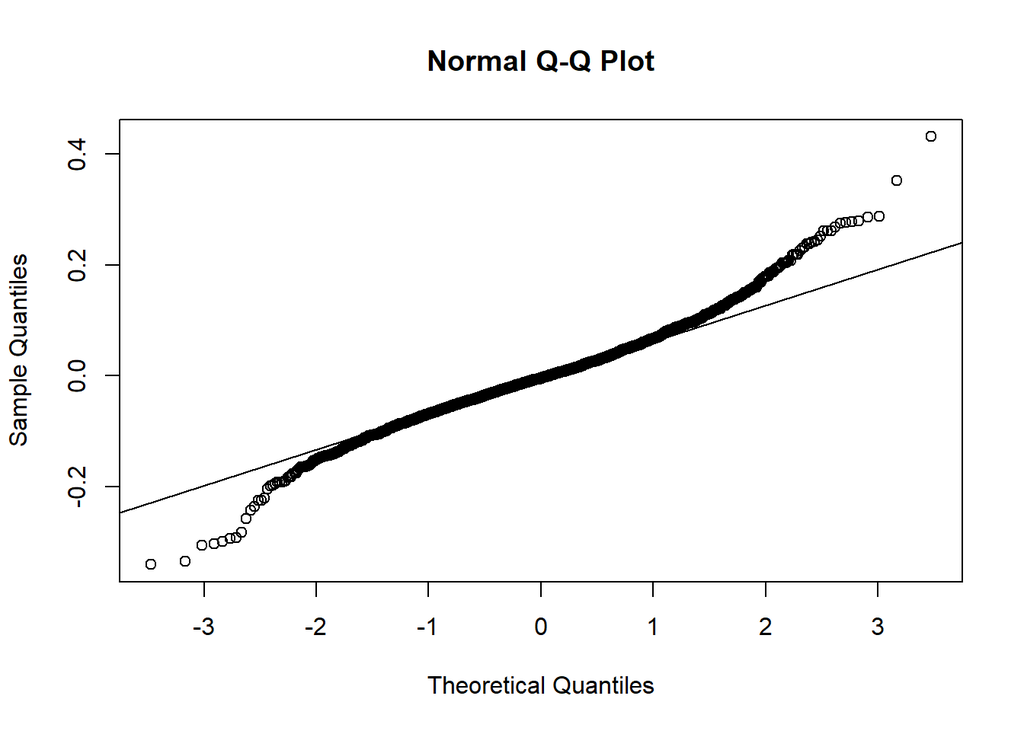

```r
#Q-Q plot
qqnorm(finalmodel$residuals)

#Add line to Q-Q plot
qqline(finalmodel$residuals)
```

### Constant Variance

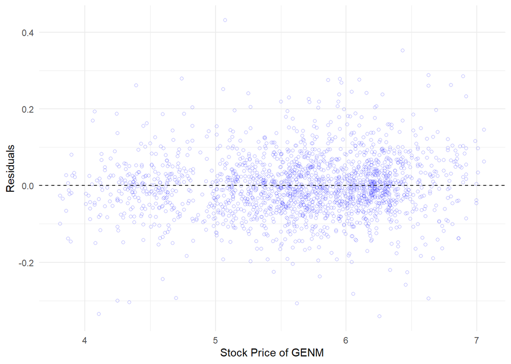

```r
#Load library
library(ggplot2)

#Create data frame
dummy_data = data.frame(data1, finalmodel$residuals)

#Residual plot
ggplot(data = dummy_data,
       aes(x = data1,
           y = finalmodel$residuals
       ))+
  geom_point(alpha = 0.3, shape = 1, colour = 'blue')+
  geom_hline(yintercept = 0, linetype = "dashed")+
  labs(y = "Residuals",
       x = "Stock Price of GENM")+
  theme_minimal()
```

### Forecasting

```r
#Predict the stock price
forecastmodel = predict(finalmodel, n.ahead = 1)
```

The stock price of Genting Malaysia for the next period is predicted based on the historical data. This step is repeated by adding a future value at a time and then predict the stock price for the next period. The overall process of this step is automated in the following code.

```r
future_value10 = c(3.36, 3.36, 3.45, 3.7, 3.67, 3.9, 3.85, 3.87, 3.82, 3.75)

#Original dataset
data2 = data[, 2]

#Subset of the original data
data2 = data.frame(data2)

#Create dummy df
data3 = data.frame(Predicted = double())

#Adding future value into original data & forecasting
for (i in 1:10){
  if (i!= 1){
    newdata1 = rbind(data2, future_value10[i-1])
    data2 = newdata1
    data2 = ts(data2)
    new_fit_model = arima(data2, order = c(2, 1, 1))
    pred = predict(new_fit_model, n.ahead = 1)
    data3[i, 1] = pred$pred
    print(pred)
  }
  else{
    pred = predict(finalmodel, n.ahead = 1)
    data3[i, 1] = pred$pred
    print(pred)
  }
}
```

```
$pred
Time Series:
Start = 1942
End = 1942
Frequency = 1
[1] 4.262459

$se
Time Series:
Start = 1942
End = 1942
Frequency = 1
[1] 0.07856651

$pred
Time Series:
Start = 1943
End = 1943
Frequency = 1
[1] 3.711204

$se
Time Series:
Start = 1943
End = 1943
Frequency = 1
[1] 0.149521

$pred
Time Series:
Start = 1944
End = 1944
Frequency = 1
[1] 3.481488

$se
Time Series:
Start = 1944
End = 1944
Frequency = 1
```

[output cut: 84 more lines]

```
[1] 0.149531

$pred
Time Series:
Start = 1951
End = 1951
Frequency = 1
[1] 3.84349

$se
Time Series:
Start = 1951
End = 1951
Frequency = 1
[1] 0.1495024
```

The predicted and actual stock price for the 10 periods are shown as below:

|  | Predicted_value | Actual_value |
| --- | --- | --- |
| 1 | 4.26 | 3.36 |
| 2 | 3.71 | 3.36 |
| 3 | 3.48 | 3.45 |
| 4 | 3.54 | 3.70 |
| 5 | 3.76 | 3.67 |
| 6 | 3.73 | 3.90 |
| 7 | 3.93 | 3.85 |
| 8 | 3.88 | 3.87 |
| 9 | 3.90 | 3.82 |
| 10 | 3.84 | 3.75 |

```r
# RMSE, MAPE
accuracy(new_fit_model)
```

```
                      ME      RMSE        MAE         MPE     MAPE
Training set -0.00410768 0.1494643 0.09765959 -0.09506921 1.151109
                 MASE          ACF1
Training set 1.000728 -0.0001584669
```

```r
#load library
library(MLmetrics)

#MSE
MSE(data3$Predicted, future_value10)
```

```
[1] 0.1025395
```